# Credit Card Fraud Detection Capstone Project - Report

Alessandro Corradini - Harvard Data Science Professional

May 24, 2019

Abstract

This is the final assignment for the Harvard Data Science Professional Program taught by the famous Prof. of Biostatistics Rafael Irizarry from Harvard University. In this capstone project, we have to choose a dataset and we have to analyze it and perform our machine learning tasks in complete autonomy without external help.

# Executive Summary

It is important that credit card companies are able to recognize fraudulent credit card transactions so that customers are not charged for items that they did not purchase. The datasets contains transactions made by credit cards in September 2013 by european cardholders.

Due to imbalancing nature of the data, many observations could be predicted as False Negative, in this case Legal Transactions instead of Fraudolent Transaction. For example, a model that predict always **0** (Legal) can archieve an Accuracy of **99.8**. For that reason, the metric used for measuring the score is the **Area Under The Precision-Recall Curve (AUCPR)** instead of the traditional AUC curve. A desiderable result is an AUCPR at least greater than **0.85**.

For archieving the task of classifying credit card fraud detection, they are trained several algorithms such as Naive Bayes Classifier, KNN, SVM, Random Forest, GBM, XGBoost and LightGBM.

# Exploratory Data Analysis

## The Dataset

This dataset presents transactions that occurred in two days, where we have **492 frauds** out of **284,807 transactions**. The dataset is highly unbalanced, the positive class (frauds) account for 0.172% of all transactions.

The dataset contains only numerical input variables which are the result of a PCA transformation. Unfortunately, due to confidentiality issues, we cannot provide the original features and more background information about the data. Features V1, V2, … V28 are the principal components obtained with PCA, the only features which have not been transformed with PCA are ‘Time’ and ‘Amount’.

**Source**

https://www.kaggle.com/mlg-ulb/creditcardfraud

**Dimensions**

| Length | Columns |
| --- | --- |
| 284807 | 31 |

**Imbalanced Dataset**

This is a very imbalanced dataset. It means that there are few rows that represent a class. In this case, only **492** transactions are frauds, represented by **1** and **284315** are not, represented by **0**.

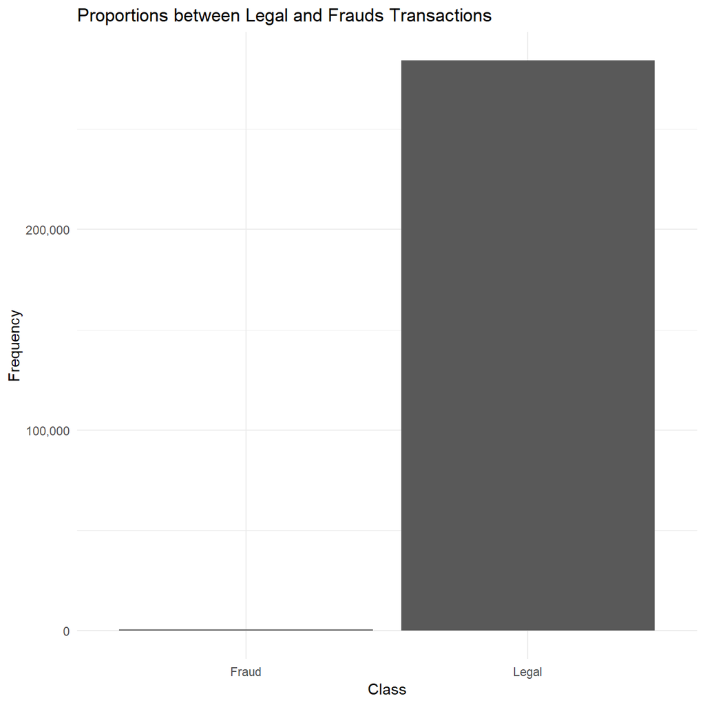

| Class | Count |
| --- | --- |
| 0 | 284315 |
| 1 | 492 |

**Missing Values**

As the table below suggests, there aren’t missing values in this dataframe.

|  | Missing Values |
| --- | --- |
| Time | 0 |
| V1 | 0 |
| V2 | 0 |
| V3 | 0 |
| V4 | 0 |
| V5 | 0 |
| V6 | 0 |
| V7 | 0 |
| V8 | 0 |
| V9 | 0 |
| V10 | 0 |
| V11 | 0 |
| V12 | 0 |
| V13 | 0 |
| V14 | 0 |
| V15 | 0 |
| V16 | 0 |
| V17 | 0 |
| V18 | 0 |
| V19 | 0 |
| V20 | 0 |
| V21 | 0 |
| V22 | 0 |
| V23 | 0 |
| V24 | 0 |
| V25 | 0 |
| V26 | 0 |
| V27 | 0 |
| V28 | 0 |
| Amount | 0 |
| Class | 0 |

**First 10 Rows of `creditcard` dataset**

| Time | V1 | V2 | V3 | V4 | V5 | V28 | Amount | Class |
| --- | --- | --- | --- | --- | --- | --- | --- | --- |
| 0 | -1.3598071 | -0.0727812 | 2.5363467 | 1.3781552 | -0.3383208 | -0.0210531 | 149.62 | 0 |
| 0 | 1.1918571 | 0.2661507 | 0.1664801 | 0.4481541 | 0.0600176 | 0.0147242 | 2.69 | 0 |
| 1 | -1.3583541 | -1.3401631 | 1.7732093 | 0.3797796 | -0.5031981 | -0.0597518 | 378.66 | 0 |
| 1 | -0.9662717 | -0.1852260 | 1.7929933 | -0.8632913 | -0.0103089 | 0.0614576 | 123.50 | 0 |
| 2 | -1.1582331 | 0.8777368 | 1.5487178 | 0.4030339 | -0.4071934 | 0.2151531 | 69.99 | 0 |
| 2 | -0.4259659 | 0.9605230 | 1.1411093 | -0.1682521 | 0.4209869 | 0.0810803 | 3.67 | 0 |
| 4 | 1.2296576 | 0.1410035 | 0.0453708 | 1.2026127 | 0.1918810 | 0.0051678 | 4.99 | 0 |
| 7 | -0.6442694 | 1.4179635 | 1.0743804 | -0.4921990 | 0.9489341 | -1.0853392 | 40.80 | 0 |
| 7 | -0.8942861 | 0.2861572 | -0.1131922 | -0.2715261 | 2.6695987 | 0.1424043 | 93.20 | 0 |
| 9 | -0.3382618 | 1.1195934 | 1.0443666 | -0.2221873 | 0.4993608 | 0.0830756 | 3.68 | 0 |

**Frauds Amount Distributions**

Small amount of money, less or equal of one dollar are scammed more frequently.

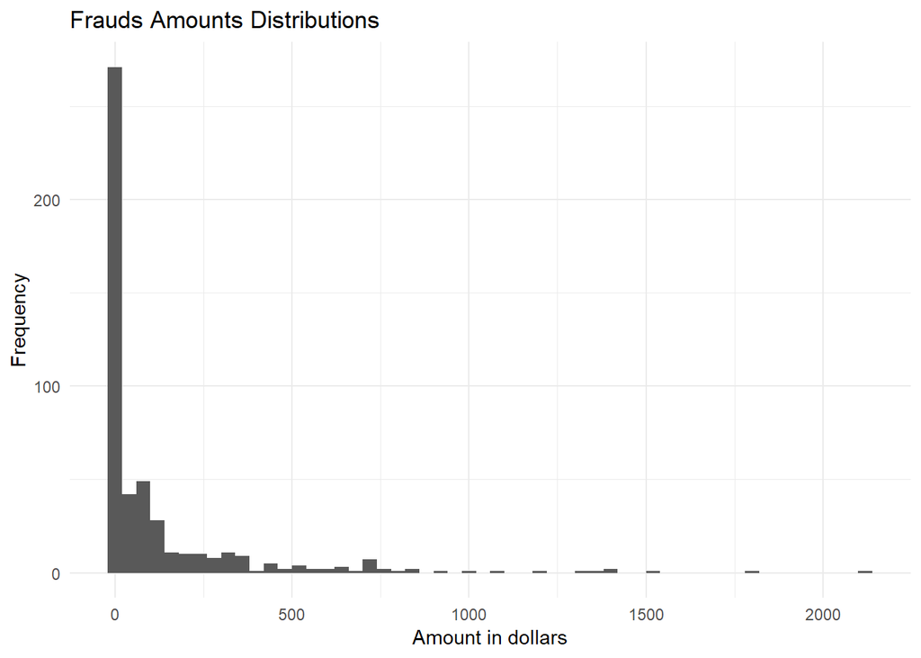

| Amount | count |
| --- | --- |
| 1.00 | 113 |
| 0.00 | 27 |
| 99.99 | 27 |
| 0.76 | 17 |
| 0.77 | 10 |
| 0.01 | 5 |
| 2.00 | 4 |
| 3.79 | 4 |
| 0.68 | 3 |
| 1.10 | 3 |

**Frauds over Time Distribution**

There aren’t correlation between `time` and frauds. A fraud can happen anytime. It seems not particularly useful for the modelling phase. The correlation matrix below, confirms this assumpion.

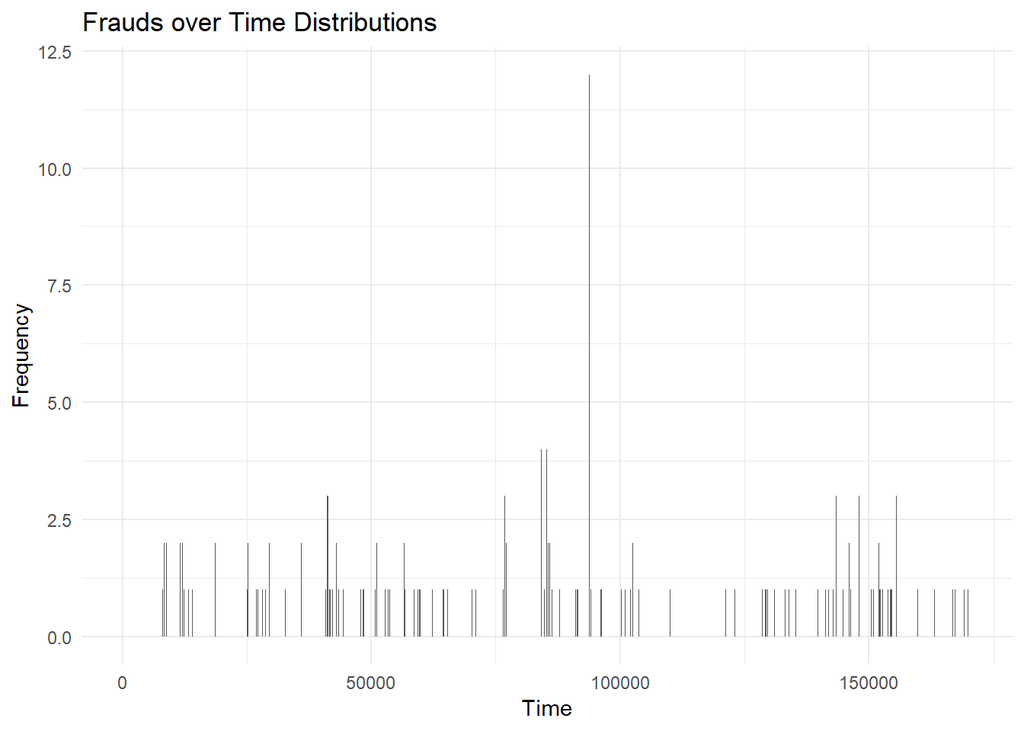

| Time | count |
| --- | --- |
| 68207 | 6 |
| 84204 | 4 |
| 85285 | 4 |
| 93853 | 4 |
| 93860 | 4 |
| 93879 | 4 |
| 94362 | 4 |
| 148053 | 2 |
| 406 | 1 |
| 472 | 1 |

**Correlations between each variables**

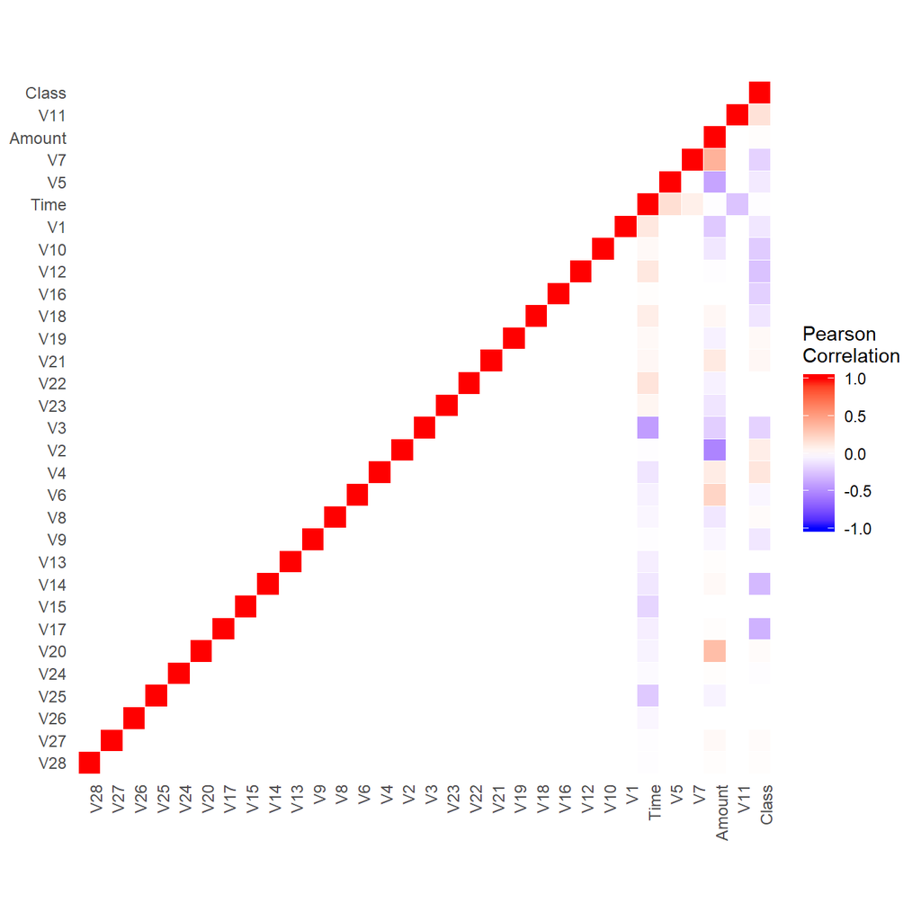

# Data Pre-Processing

Before continuing to build models, It have to do a little data pre-processing:

1. Remove the “Time” column from the dataset. It isn’t useful.
2. Split the dataset into train, test, cv dataset.

# Analysis - Models Building and Comparison

## Naive Baseline Algorithm - Predict Always “Legal” Transaction

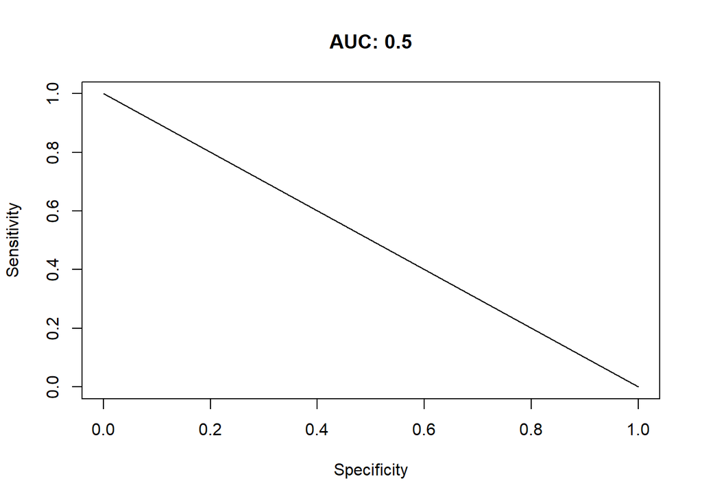

[figure not shown]

| Model | AUC | AUCPR |
| --- | --- | --- |
| Naive Baseline - Predict Always Legal | 0.5 | 0 |

## Naive Bayes

A step forward is building a Naive Bayes Classifier. The performance improve a little bit: AUC is **0.92** and finally the there is an AUCPR of **0.05**. It is a poor result according to the metric of interest and it is easy to improve.

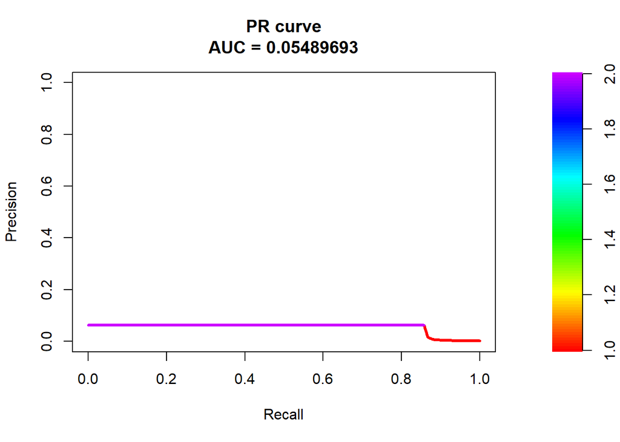

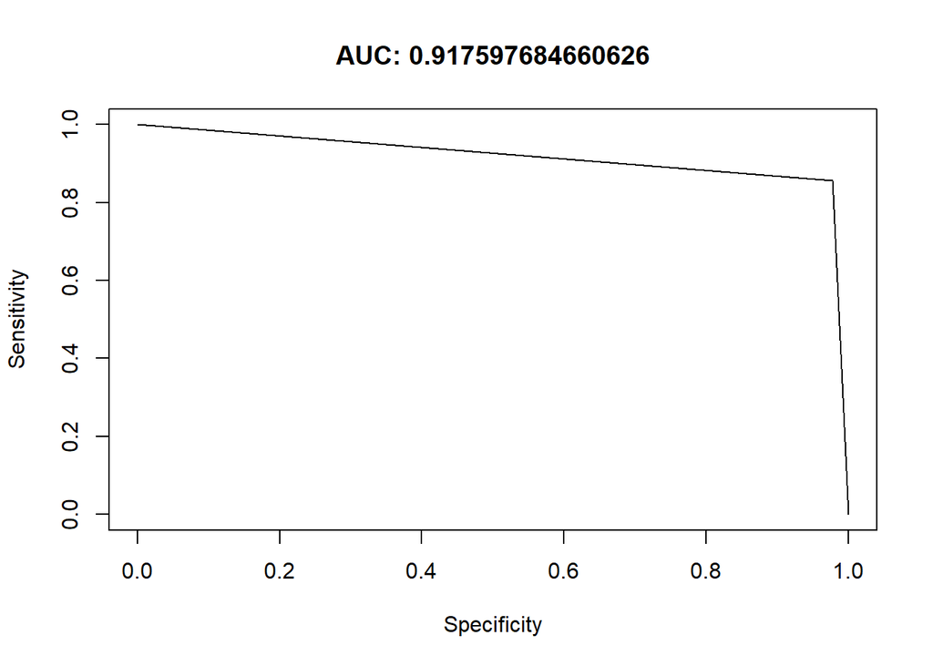

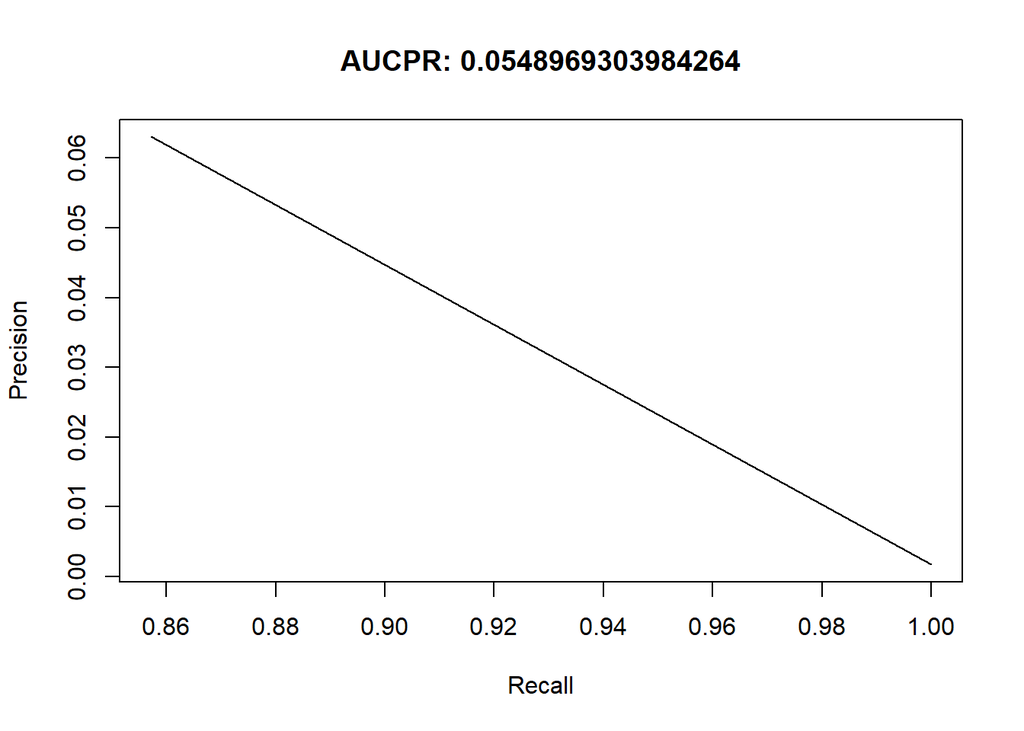

| Model | AUC | AUCPR |
| --- | --- | --- |
| Naive Baseline - Predict Always Legal | 0.5000000 | 0.0000000 |
| Naive Bayes | 0.9175977 | 0.0548969 |

## KNN - K-Nearest Neighbors

A KNN Model with k=5 can achieve a significant improvement in respect to the previous models, as regard AUCPR of **0.58** at the expense of a little drop off AUC, that is **0.81**.

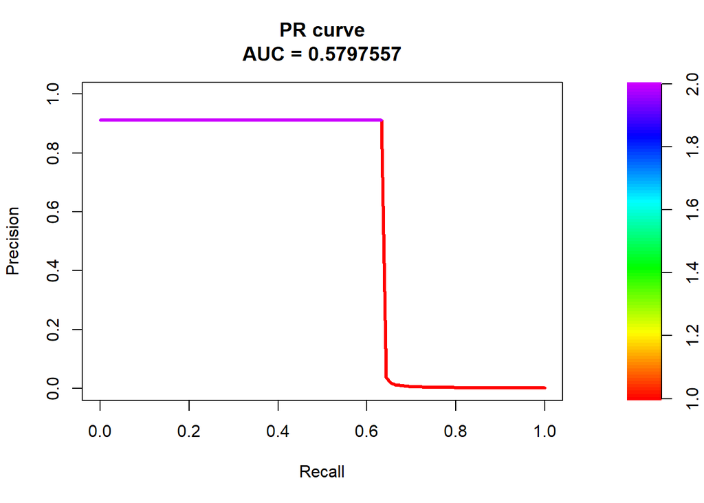

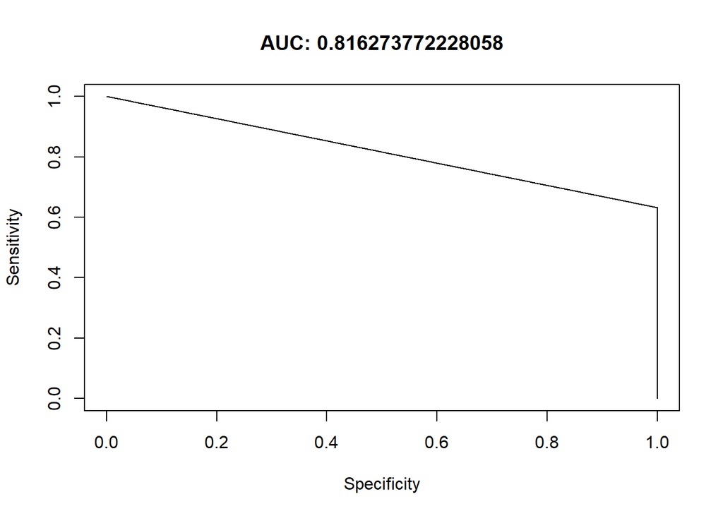

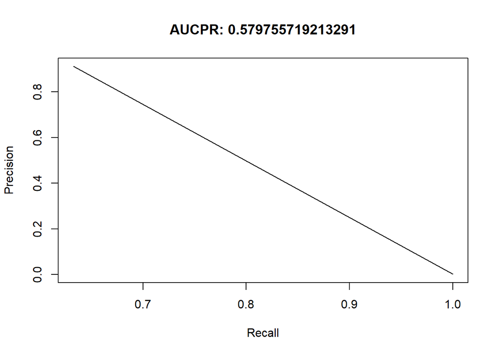

| Model | AUC | AUCPR |
| --- | --- | --- |
| Naive Baseline - Predict Always Legal | 0.5000000 | 0.0000000 |
| Naive Bayes | 0.9175977 | 0.0548969 |
| K-Nearest Neighbors k=5 | 0.8162738 | 0.5797557 |

## SVM - Support Vector Machine

The SVM Model with a Sigmoid Kernel represent a step back on all fronts because the AUCPR is **0.32** and AUC is **0.77**.

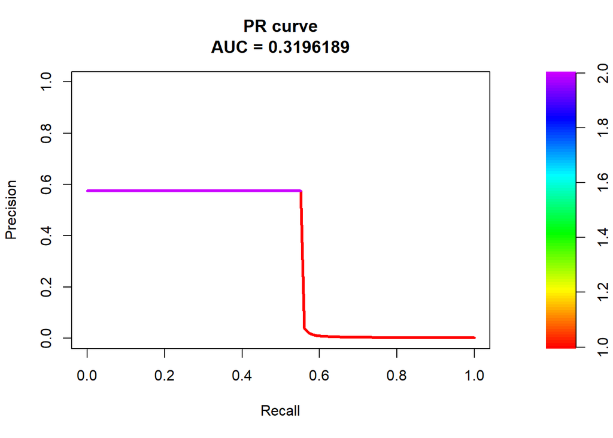

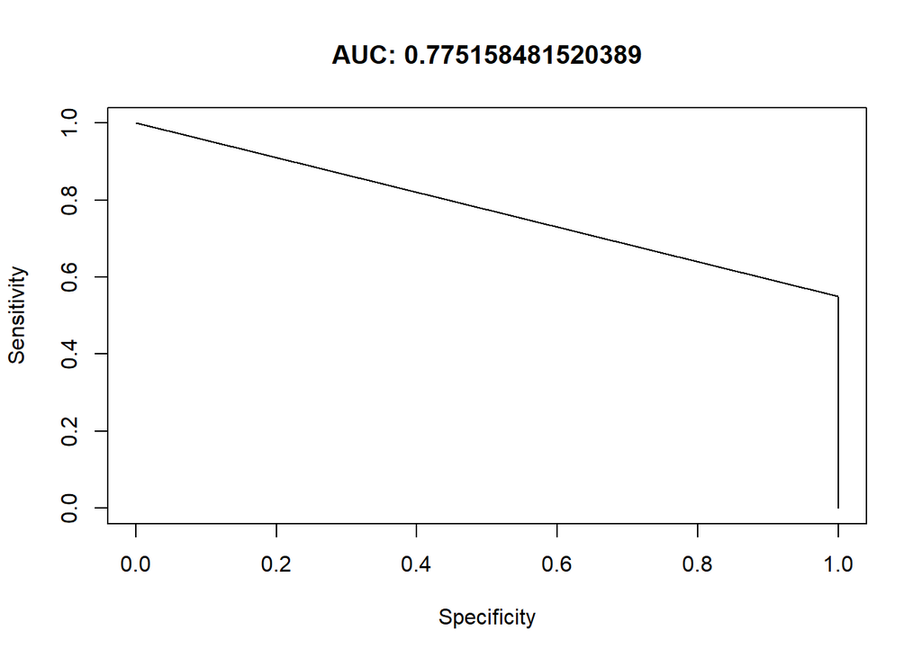

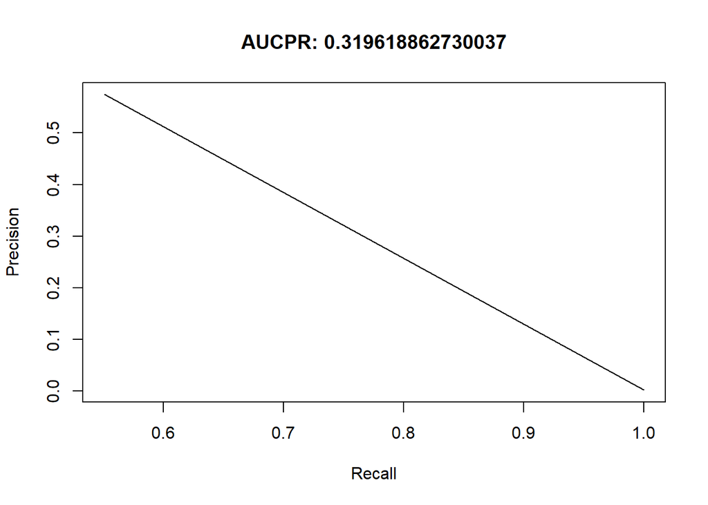

| Model | AUC | AUCPR |
| --- | --- | --- |
| Naive Baseline - Predict Always Legal | 0.5000000 | 0.0000000 |
| Naive Bayes | 0.9175977 | 0.0548969 |
| K-Nearest Neighbors k=5 | 0.8162738 | 0.5797557 |
| SVM - Support Vector Machine | 0.7751585 | 0.3196189 |

## Random Forest

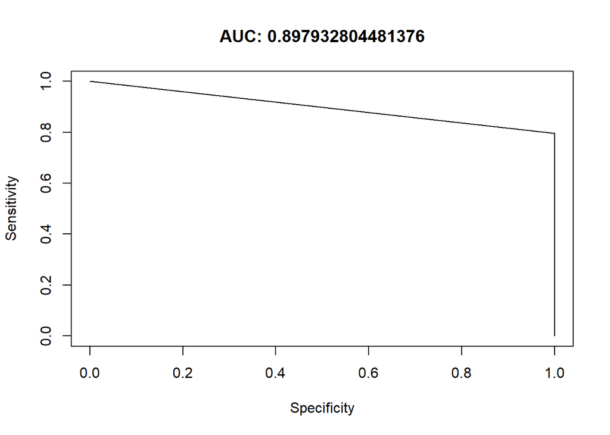

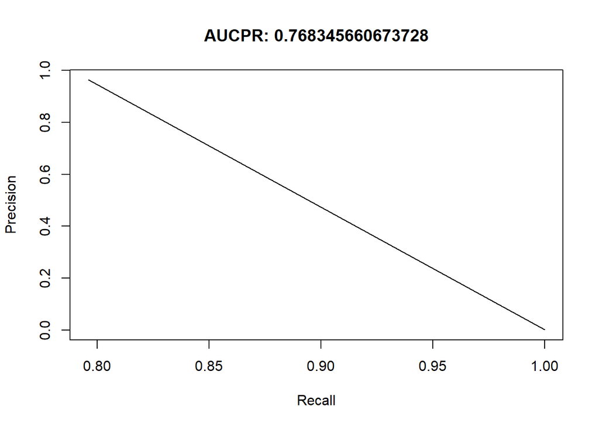

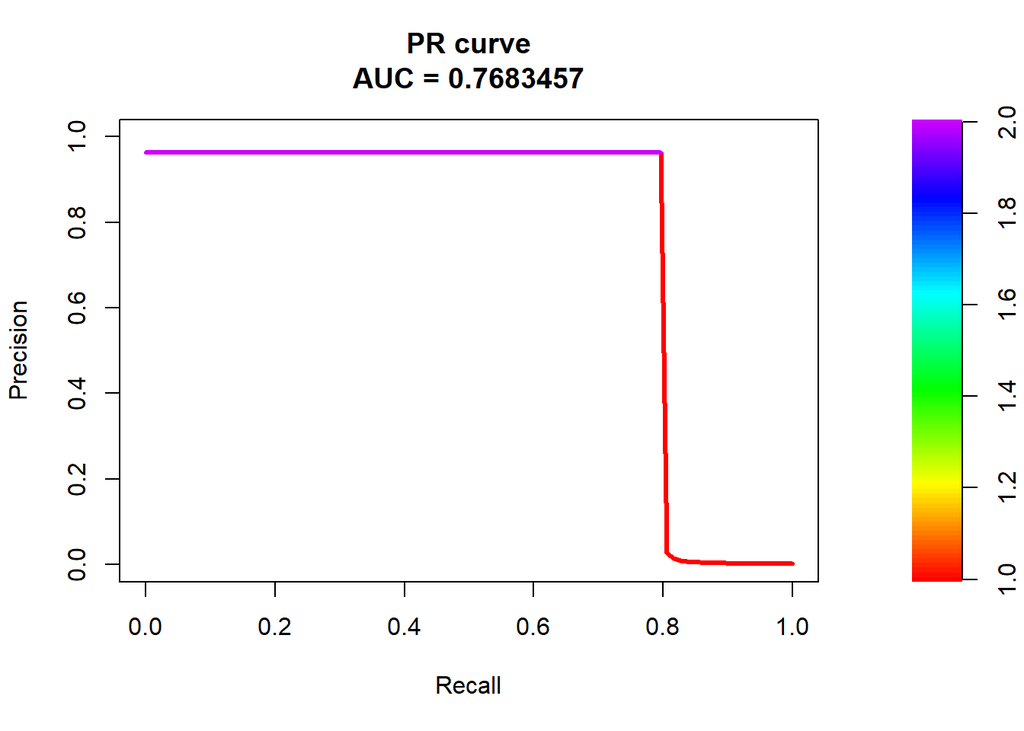

| Model | AUC | AUCPR |
| --- | --- | --- |
| Naive Baseline - Predict Always Legal | 0.5000000 | 0.0000000 |
| Naive Bayes | 0.9175977 | 0.0548969 |
| K-Nearest Neighbors k=5 | 0.8162738 | 0.5797557 |
| SVM - Support Vector Machine | 0.7751585 | 0.3196189 |
| Random Forest | 0.8979328 | 0.7683457 |

|  | MeanDecreaseGini |
| --- | --- |
| V1 | 8.708982 |
| V2 | 7.784292 |
| V3 | 8.985490 |
| V4 | 17.257080 |
| V5 | 7.772203 |
| V6 | 8.821890 |
| V7 | 19.072039 |
| V8 | 7.013489 |
| V9 | 23.520504 |
| V10 | 43.772484 |
| V11 | 44.997607 |
| V12 | 73.056009 |
| V13 | 6.829304 |
| V14 | 63.479173 |
| V15 | 6.388524 |
| V16 | 40.124086 |
| V17 | 105.084852 |
| V18 | 16.236771 |
| V19 | 8.041600 |
| V20 | 8.359602 |
| V21 | 10.723973 |
| V22 | 5.886333 |
| V23 | 4.705090 |
| V24 | 6.127916 |
| V25 | 5.290926 |
| V26 | 10.888757 |
| V27 | 9.216603 |
| V28 | 6.266699 |
| Amount | 7.974071 |

## GBM - Generalized Boosted Regression

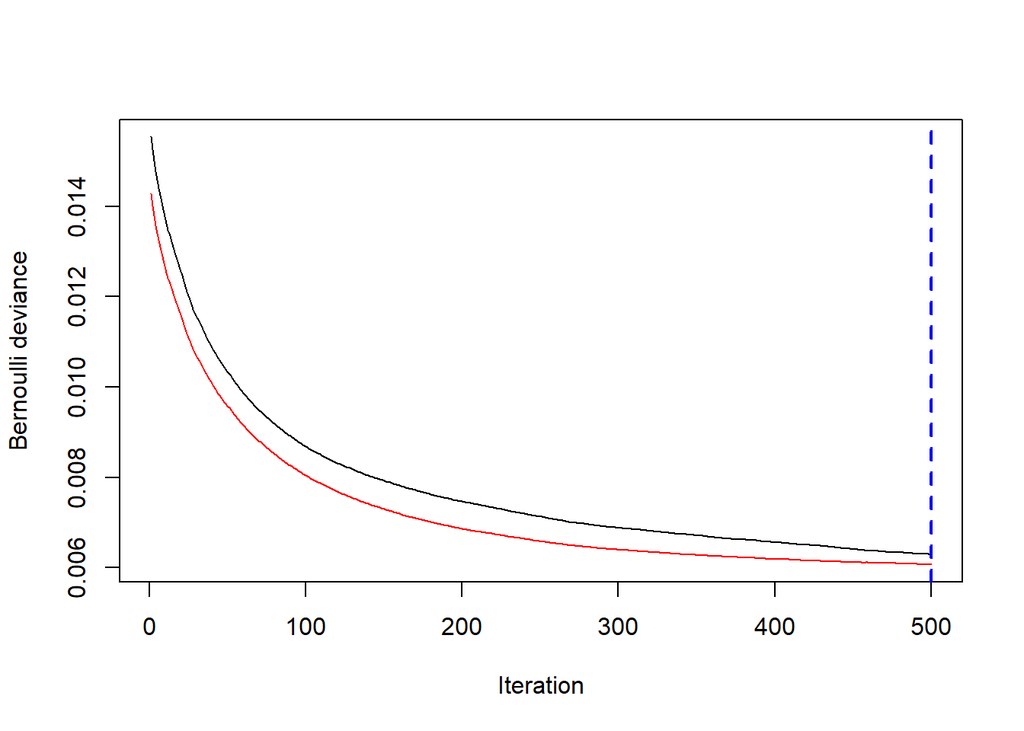

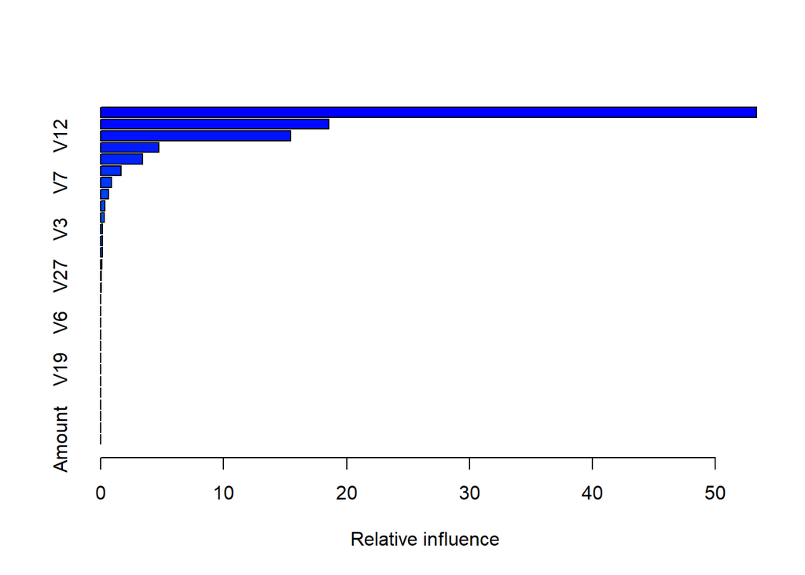

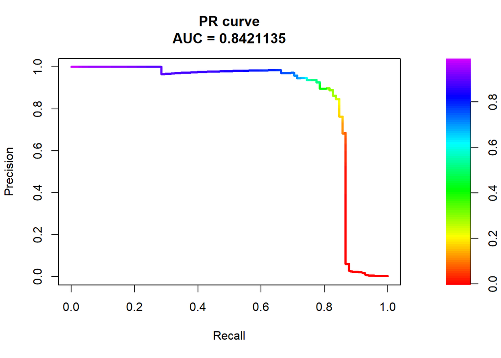

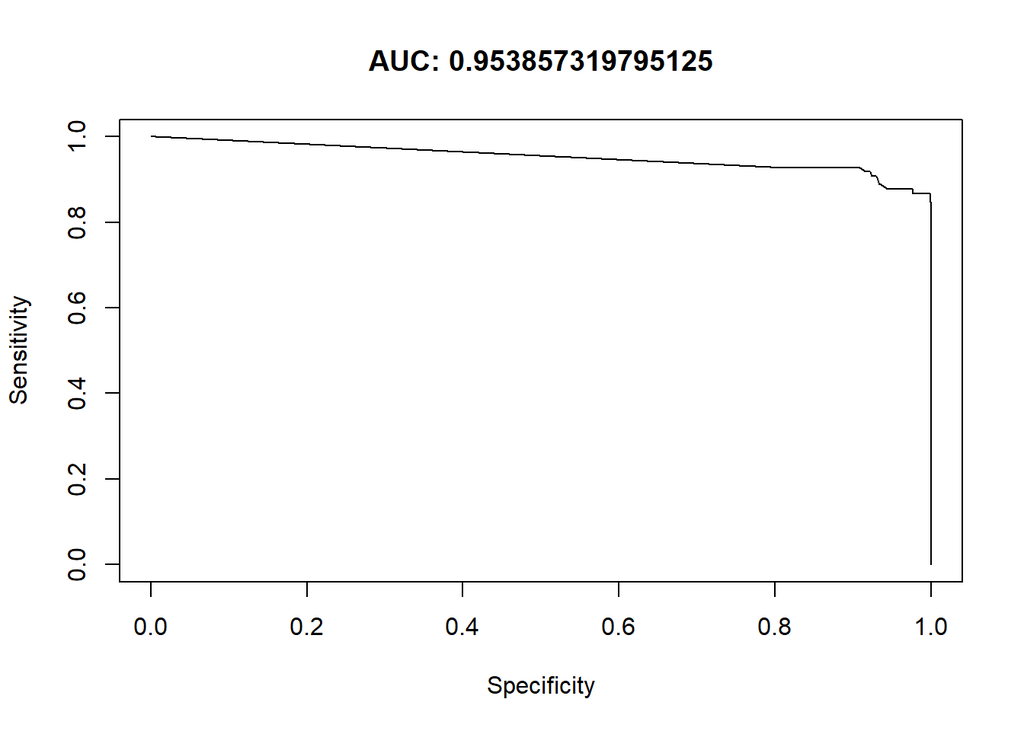

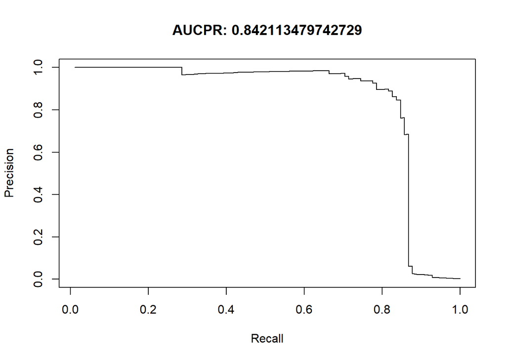

| Model | AUC | AUCPR |
| --- | --- | --- |
| Naive Baseline - Predict Always Legal | 0.5000000 | 0.0000000 |
| Naive Bayes | 0.9175977 | 0.0548969 |
| K-Nearest Neighbors k=5 | 0.8162738 | 0.5797557 |
| SVM - Support Vector Machine | 0.7751585 | 0.3196189 |
| Random Forest | 0.8979328 | 0.7683457 |
| GBM - Generalized Boosted Regression | 0.9538573 | 0.8421135 |

|  | var | rel.inf |
| --- | --- | --- |
| V17 | V17 | 53.3300209 |
| V14 | V14 | 18.5530357 |
| V12 | V12 | 15.4550412 |
| V10 | V10 | 4.7219307 |
| V20 | V20 | 3.3949817 |
| V11 | V11 | 1.6650329 |
| V7 | V7 | 0.8612551 |
| V9 | V9 | 0.6445507 |
| V4 | V4 | 0.3346926 |
| V26 | V26 | 0.3156347 |
| V3 | V3 | 0.1467431 |
| V28 | V28 | 0.1435442 |
| V18 | V18 | 0.1392624 |
| V16 | V16 | 0.0918682 |
| V27 | V27 | 0.0711635 |
| V25 | V25 | 0.0489084 |
| V8 | V8 | 0.0172958 |
| V5 | V5 | 0.0155866 |
| V6 | V6 | 0.0147381 |
| V15 | V15 | 0.0134430 |
| V21 | V21 | 0.0114564 |
| V22 | V22 | 0.0074806 |
| V19 | V19 | 0.0019186 |
| V1 | V1 | 0.0004148 |
| V2 | V2 | 0.0000000 |
| V13 | V13 | 0.0000000 |
| V23 | V23 | 0.0000000 |
| V24 | V24 | 0.0000000 |
| Amount | Amount | 0.0000000 |

## XGBoost

XGBoost are a top class model. It always stays on TOP5 (or wins them) in every competitions on Kaggle and in this case, its’ very fast to train and its performance are awesome. With an AUC of **0.98** and an AUCPR of **0.86** it reach and overtake the desidered performance. As the previous model shown, **V17** and **V14** are still relevant to predict a fraud.

[output not shown]

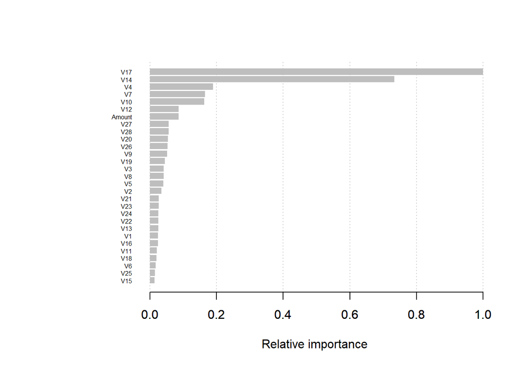

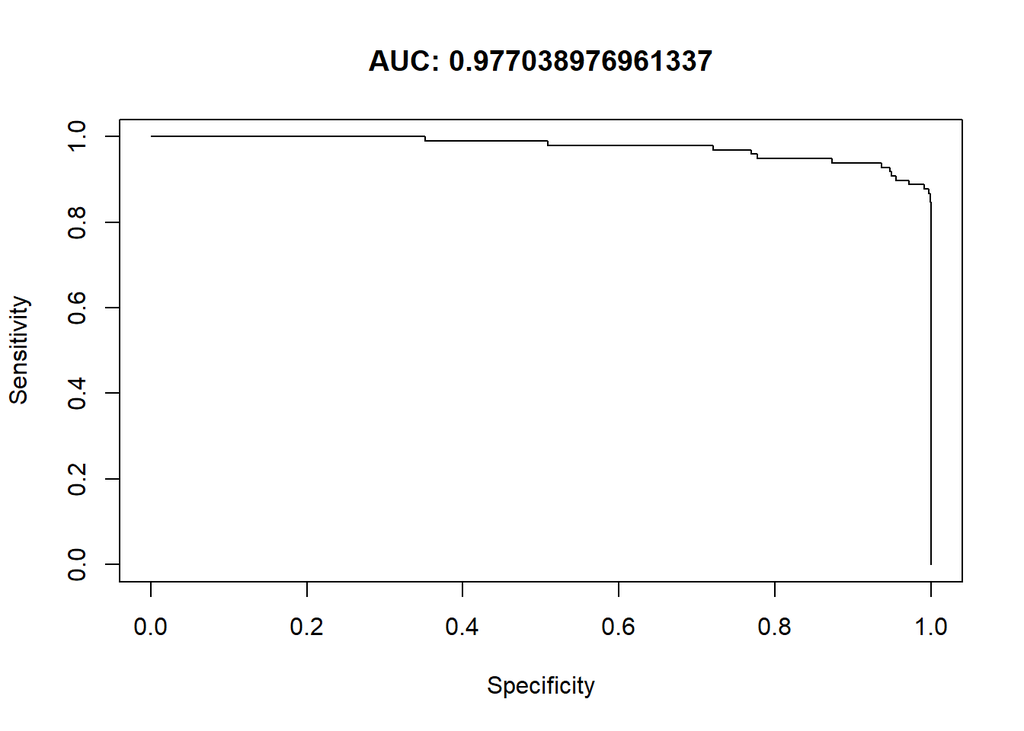

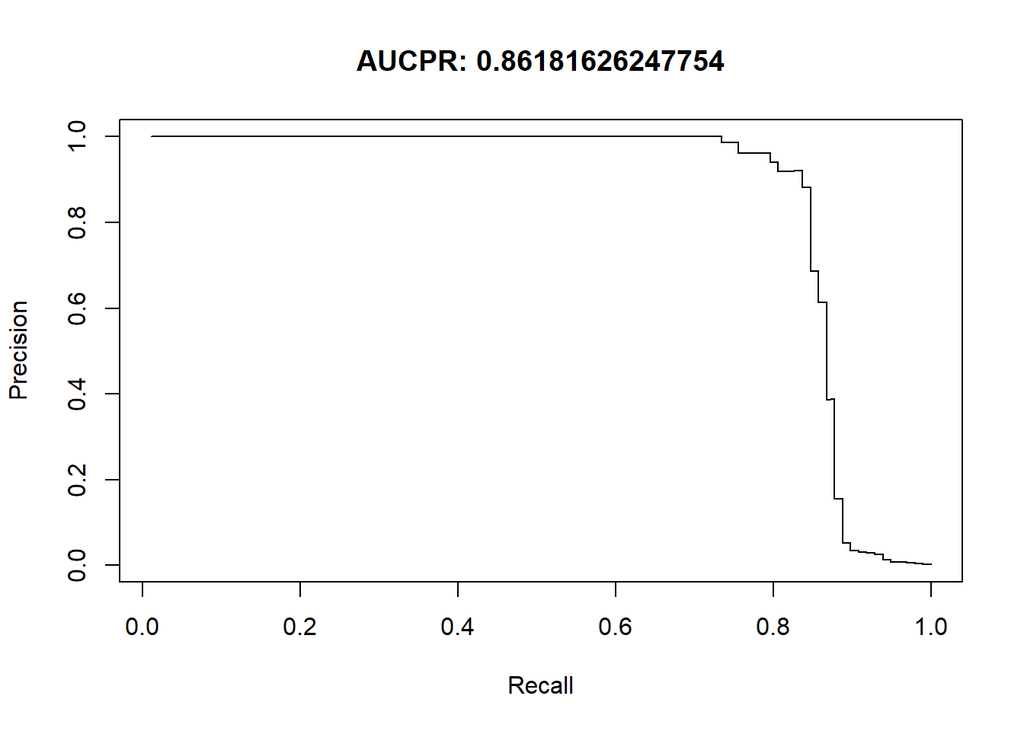

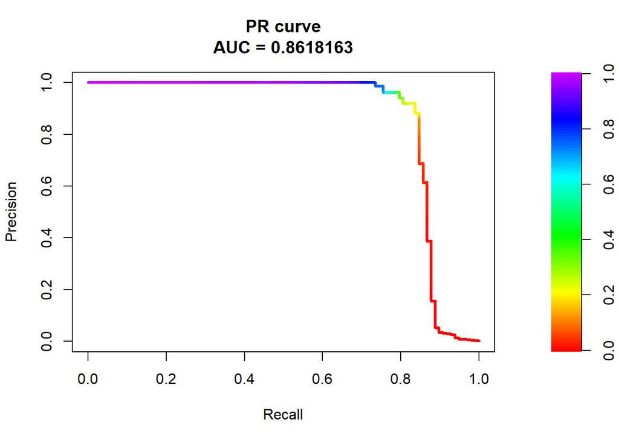

| Model | AUC | AUCPR |
| --- | --- | --- |
| Naive Baseline - Predict Always Legal | 0.5000000 | 0.0000000 |
| Naive Bayes | 0.9175977 | 0.0548969 |
| K-Nearest Neighbors k=5 | 0.8162738 | 0.5797557 |
| SVM - Support Vector Machine | 0.7751585 | 0.3196189 |
| Random Forest | 0.8979328 | 0.7683457 |
| GBM - Generalized Boosted Regression | 0.9538573 | 0.8421135 |
| XGBoost | 0.9770390 | 0.8618163 |

| Feature | Gain | Cover | Frequency | Importance |
| --- | --- | --- | --- | --- |
| V17 | 0.3171657 | 0.3376839 | 0.0590406 | 0.3171657 |
| V14 | 0.2328285 | 0.4247761 | 0.0974170 | 0.2328285 |
| V4 | 0.0600361 | 0.0149544 | 0.0900369 | 0.0600361 |
| V7 | 0.0524206 | 0.0016778 | 0.0487085 | 0.0524206 |
| V10 | 0.0515966 | 0.0024414 | 0.0442804 | 0.0515966 |
| V12 | 0.0274032 | 0.1442810 | 0.0457565 | 0.0274032 |
| Amount | 0.0270669 | 0.0014754 | 0.0568266 | 0.0270669 |
| V27 | 0.0179538 | 0.0006398 | 0.0265683 | 0.0179538 |
| V28 | 0.0178111 | 0.0008319 | 0.0324723 | 0.0178111 |
| V20 | 0.0171806 | 0.0008593 | 0.0250923 | 0.0171806 |
| V26 | 0.0166046 | 0.0006860 | 0.0332103 | 0.0166046 |
| V9 | 0.0161372 | 0.0059450 | 0.0265683 | 0.0161372 |
| V19 | 0.0139521 | 0.0008483 | 0.0346863 | 0.0139521 |
| V3 | 0.0129482 | 0.0014248 | 0.0391144 | 0.0129482 |
| V8 | 0.0128923 | 0.0008873 | 0.0280443 | 0.0128923 |
| V5 | 0.0125336 | 0.0188990 | 0.0324723 | 0.0125336 |
| V2 | 0.0106854 | 0.0006103 | 0.0228782 | 0.0106854 |
| V21 | 0.0084312 | 0.0007444 | 0.0191882 | 0.0084312 |
| V23 | 0.0083561 | 0.0280382 | 0.0265683 | 0.0083561 |
| V24 | 0.0079779 | 0.0005232 | 0.0250923 | 0.0079779 |
| V22 | 0.0079069 | 0.0011115 | 0.0228782 | 0.0079069 |
| V13 | 0.0077632 | 0.0008035 | 0.0243542 | 0.0077632 |
| V1 | 0.0076040 | 0.0006159 | 0.0295203 | 0.0076040 |
| V16 | 0.0076017 | 0.0069315 | 0.0258303 | 0.0076017 |
| V11 | 0.0066428 | 0.0006218 | 0.0177122 | 0.0066428 |
| V18 | 0.0060901 | 0.0004219 | 0.0199262 | 0.0060901 |
| V6 | 0.0054157 | 0.0004609 | 0.0169742 | 0.0054157 |
| V25 | 0.0045781 | 0.0004818 | 0.0169742 | 0.0045781 |
| V15 | 0.0044156 | 0.0003236 | 0.0118081 | 0.0044156 |

## LightGBM

LightGBM is the fastest and complex implementation of GBM. It has tons of parameters and because of this it has a steep learning curve. With a small changen of the parameters, the LightGBM model is able to reach the performance of XGBoost. Because I’have more experience with the last one, the performance are a little bit worse: AUC of **0.94** and AUCPR of **0.85**, but they are all good.

```
## [1]: test's binary_error:0.00172048  cv's binary_error:0.00172048
## [21]:    test's binary_error:0.0016327   cv's binary_error:0.00156247
## [41]:    test's binary_error:0.000842682 cv's binary_error:0.00080757
## [61]:    test's binary_error:0.000842682 cv's binary_error:0.000790014
## [81]:    test's binary_error:0.000702235 cv's binary_error:0.000719791
## [101]:   test's binary_error:0.000614456 cv's binary_error:0.000667123
## [121]:   test's binary_error:0.000544232 cv's binary_error:0.000579344
## [141]:   test's binary_error:0.000474009 cv's binary_error:0.000561788
## [161]:   test's binary_error:0.000456453 cv's binary_error:0.000526676
## [181]:   test's binary_error:0.000456453 cv's binary_error:0.00050912
## [201]:   test's binary_error:0.000456453 cv's binary_error:0.00050912
```

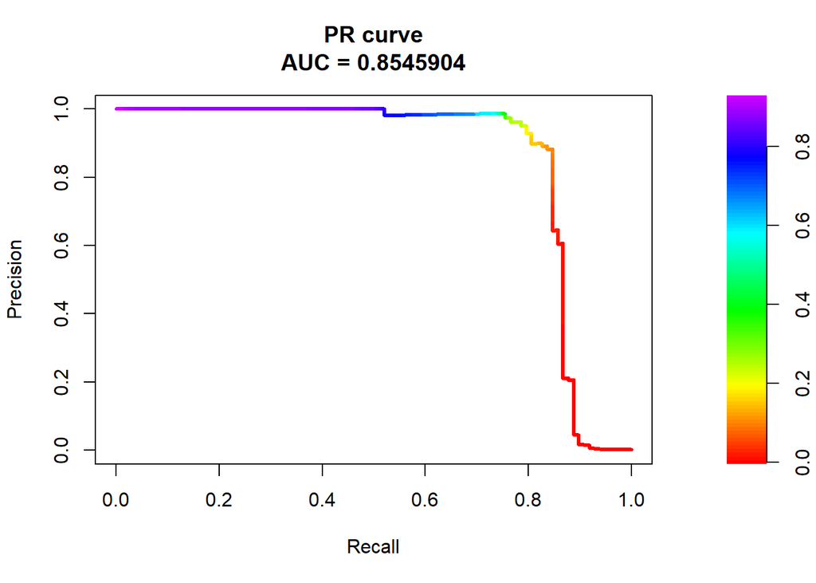

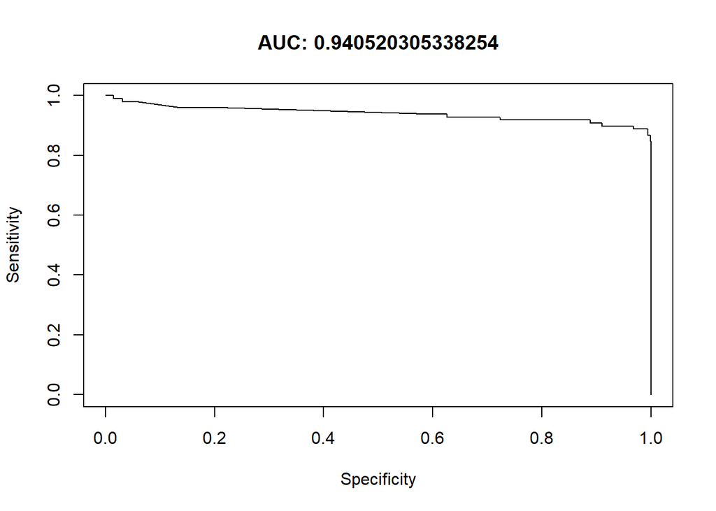

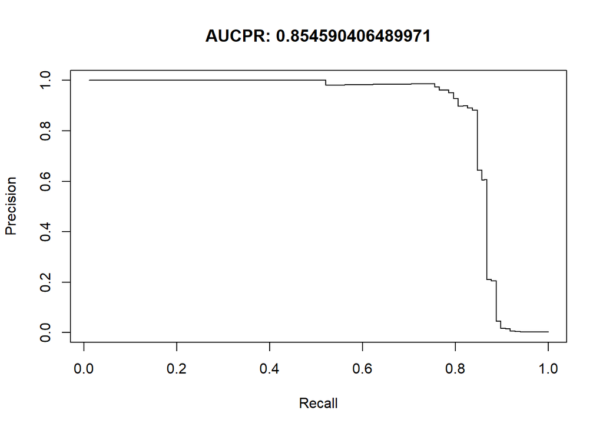

| Model | AUC | AUCPR |
| --- | --- | --- |
| Naive Baseline - Predict Always Legal | 0.5000000 | 0.0000000 |
| Naive Bayes | 0.9175977 | 0.0548969 |
| K-Nearest Neighbors k=5 | 0.8162738 | 0.5797557 |
| SVM - Support Vector Machine | 0.7751585 | 0.3196189 |
| Random Forest | 0.8979328 | 0.7683457 |
| GBM - Generalized Boosted Regression | 0.9538573 | 0.8421135 |
| XGBoost | 0.9770390 | 0.8618163 |
| LightGBM | 0.9405203 | 0.8545904 |

| Feature | Gain | Cover | Frequency |
| --- | --- | --- | --- |
| V14 | 0.4307962 | 0.3609848 | 0.0904762 |
| V7 | 0.3035386 | 0.0323388 | 0.0304348 |
| V12 | 0.0348256 | 0.0182142 | 0.0577640 |
| V26 | 0.0338785 | 0.0063473 | 0.0654244 |
| V10 | 0.0248953 | 0.0058810 | 0.0414079 |
| V4 | 0.0243032 | 0.2500562 | 0.0921325 |
| V20 | 0.0182291 | 0.0506729 | 0.0399586 |
| V1 | 0.0093899 | 0.0008671 | 0.0252588 |
| V18 | 0.0091918 | 0.0018870 | 0.0320911 |
| V2 | 0.0086183 | 0.0015763 | 0.0225673 |
| V16 | 0.0084501 | 0.0038963 | 0.0236025 |
| V13 | 0.0082319 | 0.0032468 | 0.0322981 |
| Amount | 0.0071959 | 0.0159475 | 0.0465839 |
| V17 | 0.0068772 | 0.0408338 | 0.0225673 |
| V28 | 0.0068020 | 0.0016715 | 0.0337474 |
| V24 | 0.0062211 | 0.0023892 | 0.0293996 |
| V15 | 0.0061126 | 0.0019022 | 0.0289855 |
| V11 | 0.0050963 | 0.0335001 | 0.0260870 |
| V6 | 0.0048581 | 0.0029185 | 0.0188406 |
| V9 | 0.0048414 | 0.0010716 | 0.0287785 |
| V3 | 0.0048409 | 0.0020941 | 0.0273292 |
| V8 | 0.0047966 | 0.0138567 | 0.0207039 |
| V27 | 0.0047570 | 0.0344483 | 0.0395445 |
| V23 | 0.0046562 | 0.0377007 | 0.0333333 |
| V25 | 0.0046264 | 0.0002474 | 0.0113872 |
| V19 | 0.0043399 | 0.0126660 | 0.0182195 |
| V22 | 0.0037440 | 0.0587793 | 0.0213251 |
| V5 | 0.0032005 | 0.0024771 | 0.0229814 |
| V21 | 0.0026854 | 0.0015272 | 0.0167702 |

# Results

This is the summary results for all the models builted, trained and validated.

| Model | AUC | AUCPR |
| --- | --- | --- |
| Naive Baseline - Predict Always Legal | 0.5000000 | 0.0000000 |
| Naive Bayes | 0.9175977 | 0.0548969 |
| K-Nearest Neighbors k=5 | 0.8162738 | 0.5797557 |
| SVM - Support Vector Machine | 0.7751585 | 0.3196189 |
| Random Forest | 0.8979328 | 0.7683457 |
| GBM - Generalized Boosted Regression | 0.9538573 | 0.8421135 |
| XGBoost | 0.9770390 | 0.8618163 |
| LightGBM | 0.9405203 | 0.8545904 |